# pyMódulo 09

Curso IE0217 Estructuras abstractas y algoritmos para ingeniería - UCR

Profesor Freddy Rojas Ch.

1/29/2021

# Lenguaje Python 3 Módulo 9

En este módulo 9 de Python 3 se van a continuar con el estudio de casos mediante ejemplos.

## Ejemplo 2.

Se neceista diseñar un sistema de control de vuelos para una línea aérea norteamericana mediante la implementación en Python. La información a considerar es la siguiente:

1. Los Vuelos tiene los siguientes atributos: Número de vuelo, Hora de Salida y Hora de Llegada
2. Un Vuelo Local (USA) tiene adicional al Vuelo (a) un Número mínimo de Pasajeros.
3. Un Vuelo Internacional tiene adicional al Vuelo (a) información del País destino.
4. Un Vuelo de Carga tiene dicional al Vuelo (a) un Peso máximo para la carga soportada.
5. Tanto los vuelos locales como los internacionales tienen una lista de Pasajeros.
6. Tanto los vuelos locales como los internacionales, deben calcular el monto total vendido a partir de la suma de los montos individuales de los pasaeros.
7. En relación a los pasajeros se debe considerar un Codigo, Nombre, PrecioTiquete, PorcentajeImpuesto y TotalPagar.
8. El monto total a pagar a su vez está dado por la siguiente fórmula: *PrecioTotal = PrecioTiquete + PorcentajeImpuesto ∗ PrecioTiquete*
9. Hay dos tipos de pasajeros: frecuentes y no frecuentes; la diferencia es que a los clientes frecuentes se les aplica un 20 % de descuento en el total a pagar.

### Consideraciones de diseño.

Se debe establecer una jerarquía y composición de clases. Todos los atributos de las clases debe disponer de métodos para modificar/obtener los datos

Debe desarrollarse un objeto para el ingreso de los datos por menú de manera que la información sea ingresada por teclado y observada en consola.

Como adicional se va a incorporar la posibilidad (al igual que el ejemplo 2) de poder asignar la información por archivo y guardar las secuencias de salida también con un archivo.

Se debe aplicar polimorfismo cuando se requiera.

## Solución.

Al igual que en el ejemplo del módulo 8 se a establecer la jerarquía de clases a utilizar. De nuevo se va a utilizar el siguiente diagrama *UML*

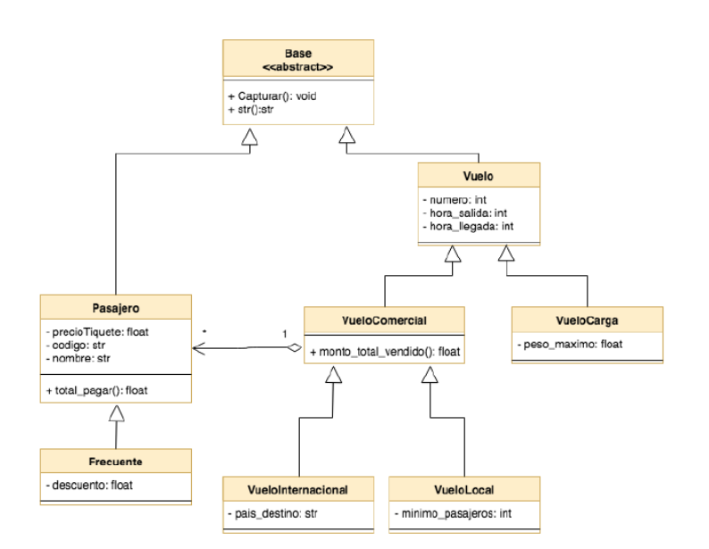

Diagrama UML que describe solución para sistema de vuelos

### Implementación.

Se realiza primero la declaración/definición de todas las *clases* necesarias.

##Base

```python
# Clases base abstractas
import sys
from abc import  ABCMeta, abstractmethod

# Clase Abstracta, ABC Class
class Base(metaclass=ABCMeta):
    @abstractmethod
    def __str__(self):
        pass

    @abstractmethod
    def Captura(self):
        pass


class BaseIO(object):
    def Input(self, info=""):
        return input(info)
```

## Declaración de clases para la implementación

#### Clase Pasajero

```python
from dateutil import parser

class Pasajero(Base, BaseIO):
    def __init__(self):
        self.__Codigo = 0
        self.__Nombre = ""
        self.__PrecioTiquete = 0.0
        self.__PorcentajeImpuesto = 0.0

    def __str__(self):
        return ("Código: %i\nPasajero %s\nPrecio tiquete %.2f\nImpuestos %.2f (%%)\nTotal a pagar %.2f\n"
                 % (self.__Codigo, self.__Nombre, self.__PrecioTiquete,
                 self.__PorcentajeImpuesto * 100, self.TotalPagar())
                )

    def Captura(self):
        self.__Nombre = self.Input("Nombre del Pasajero:")
        self.__Codigo = int(self.Input("Código de pasajero:"))
        self.__PrecioTiquete = float(self.Input("Precio del tiquete a pagar ($):"))
        self.__PorcentajeImpuesto = float(self.Input("Porcentaje de impuestos (%):")) / 100.0

    @property
    def Codigo(self):
        return self.__Codigo

    @Codigo.setter
    def Codigo(self, Codigo):
        self.__Codigo = Codigo

    @property
    def Nombre(self):
        return (self.__Nombre)

    @property
    def PrecioTiquete(self):
        return self.__PrecioTiquete

    @PrecioTiquete.setter
    def PrecioTiquete(self, precioTiquete):
        self.__PrecioTiqueteo = precioTiquete

    @property
    def PorcentajeImpuesto(self):
        return self.__PorcentajeImpuesto

    @PorcentajeImpuesto.setter
    def PorcentajeImpuesto(self, porcentajeImpuesto):
        self.__PorcentajeImpuesto = porcentajeImpuesto

    def TotalPagar(self):
        return (self.__PrecioTiquete + self.__PorcentajeImpuesto *
                self.__PrecioTiquete)
```

### Clase Pasajero Frecuente

```python
# Clase heredada de pasajeros
############################
class PasajeroFrecuente(Pasajero):
    def TotalPagar(self):
        super().__init__()
        return super().TotalPagar() * 0.8
```

### Clase Vuelo

```python
# Clases Vuelo
#################
class Vuelo(Base, BaseIO) :
    def __init__(self):
        self.__Numero = 0
        self.__HoraSalida = parser.parse("Apr 2 2018 12:00AM")
        self.__HoraLlegada = parser.parse("Apr 2 2018 12:00AM")
        self.__lista = list()

    # Método polimórfico para extender str y obtener _str_ de clases hijas
    @abstractmethod
    def __extstr__(self):
      pass

    # Método polimórfico para extender Captura y obtener nuevas entradas de clases hijas
    @abstractmethod
    def __extCaptura__(self):
      pass

    @property
    def NumeroVuelo(self) :
      return self.__Numero

    @NumeroVuelo.setter
    def NumeroVuelo(self, numero) :
      self.__Numero = numero

    @property
    def HoraSalida(self) :
      return self.__Hora_salida

    @HoraSalida.setter
    def HoraSalida(self, horaSalida) :
      self.__HoraSalida = horaSalida

    @property
    def HoraLlegada(self) :
      return self.__Hora_llegada

    @HoraLlegada.setter
    def Hora_llegada(self, horaLlegada) :
      self.__HoraLlegada = horaLlegada

    def __str__(self):
        hora1 = str(self.__HoraSalida)
        hora2 = str(self.__HoraLlegada)
        DatosVuelo = ("Número Vuelo: %s\nHora Salida %s\nHora Llegada %s\n"
                 % (self.__Numero, hora1, hora2))
        DatosVuelo += "Venta total del vuelo =%.2f\n" % (self.TotalVendido())
        DatosVuelo += self.__extstr__() + "\n"  # Obtiene atributos exdendidos según la clase hija
        for p in self.__lista:
            DatosVuelo += str(p)
        return(DatosVuelo)

    def Captura(self):
        self.__Numero = self.Input("Número de Vuelo:")
        self.__HoraSalida = parser.parse(self.Input("Fecha y hora Salida  (Apr 2 2018 12:00AM): "))
        self.__HoraLlegada = parser.parse(self.Input("Fecha y hora llegada (Apr 2 2018 12:00AM): "))
        self.__extCaptura__()

    def AssignarListaPasajeros(self, lista):
        self.__lista = lista

    def TotalVendido(self):
        total = 0.0
        for p in self.__lista:
            total += p.TotalPagar()
        return total
```

### Clase Vuelo Local

```python
# Clase heredada VueloLocal
############################
class VueloLocal(Vuelo) :
    def __init__(self):
        super().__init__()
        self.__Numero_minimo_pasajeros = 10

    def __extCaptura__(self):
        self.__Numero_minimo_pasajeros = int(self.Input("Numero mínimo de pasajeros: "))

    def __extstr__(self):
        return "Número mínimo de pasajeros: %i" % (self.__Numero_minimo_pasajeros)
```

### Clase Vuelo internacional

```python
# Clase heredada  VueloInternacional
#####################################
class VueloInternacional(Vuelo):
    def __init__(self):
        super().__init__()
        self.__PaisDestino = ""

    def __extCaptura__(self):
        self.__PaisDestino = self.Input("País destino: ")

    def __extstr__(self):
        return "País destino: %s" % (self.__PaisDestino)
```

### Clase Vuelo de carga

```python
# Clases VueloCarga
####################
class VueloCarga(Vuelo):
    def __init__(self):
        super().__init__()
        self.__PesoMaximo_carga = 500.0

    def __extCaptura__(self):
        self.__PesoMaximo_carga = float(self.Input("Peso de carga máximo: "))

    def __extstr__(self):
        return "Peso máximo: %f" % (self.__PesoMaximo_carga)
```

## Evaluación de aplicación.

La siguiente declaración permite la insercción de información mediante menús.

```python
# #CONTENEDOR DE APPLLICACION
class AppVuelos(BaseIO):
    def __init__(self):
        self.__lista = list()

    def __menuPasajeros(self):
        print(" ==================================================== ")
        print(" [1] Insertar Pasajero frecuente")
        print(" [2] Insertar Pasajero no frecuente")
        print(" [3] Ver Pasajeros en vuelo")
        print(" [4] Borrar lista completa de pasajeros")
        print(" [0] Salir y retornar lista")
        print(" ==================================================== ")
        return self.Input("> ")

    def __EnlistarPasajeros(self, Vuelo):
        lista = list()
        respuesta = ""
        while respuesta != "0":
            respuesta = self.__menuPasajeros()
            if respuesta == "1":
                print("Asigando pasajero frecuente a vuelo local número %s" % Vuelo)
                pasajero = PasajeroFrecuente()
                pasajero.Captura()
                lista.append(pasajero)

            elif respuesta == "2":
                print("Asigando pasajero NO frecuente a vuelo local número %s" % Vuelo)
                pasajero = Pasajero()
                pasajero.Captura()
                lista.append(pasajero)

            elif respuesta == "3":
                print("Mostrando lista de pasajeros a vuelo local número %s" % Vuelo)
                for i in range(len(lista)):
                    print(lista[i])
                self.Input("Digite cualquier tecla para continuar")

            elif respuesta == "4":
                print("Se ha borrado la lista de pasajeros del local número %s" % Vuelo)
                lista.clear()
                self.Input("Digite cualquier tecla para continuar")
        return lista

    def __menuPrincipal(self):
        print(" ==================================================== ")
        print(" [1] Insertar vuelo local (con pasajeros)")
        print(" [2] Insertar vuelo internacional (con pasajeros)")
        print(" [3] Insertar vuelo carga")
        print(" [4] Ver vuelos")
        print(" [5] Borrar lista completa de vuelos")
        print(" [0] Salir")
        print(" ==================================================== ")
        return self.Input("> ")

    def __mostrarLista(self):
        for i in range(len(self.__lista)):
            print(self.__lista[i])

    def RUN(self):
        respuesta = ""
        while respuesta != "0":
            respuesta = self.__menuPrincipal()
            if respuesta == "1":
                print("Asingando vuelo local")
                vuelo_local = VueloLocal()
                vuelo_local.Captura()
                pasajeros = self.__EnlistarPasajeros(vuelo_local.NumeroVuelo)
                vuelo_local.AssignarListaPasajeros(pasajeros)
                self.__lista.append(vuelo_local)

            elif respuesta == "2":
                print("Asingando vuelo internacional")
                vuelo_internacional = VueloInternacional()
                vuelo_internacional.Captura()
                pasajeros = self.__EnlistarPasajeros(vuelo_internacional.NumeroVuelo)
                vuelo_internacional.AssignarListaPasajeros(pasajeros)
                self.__lista.append(vuelo_internacional)

            elif respuesta == "3":
                print("Asingando vuelo de carga")
                vuelo_carga = VueloCarga()
                vuelo_carga.Captura()
                self.__lista.append(vuelo_carga)

            elif respuesta == "4":
                print("Ver todos los vuelos detallados")
                self.__mostrarLista()
                self.Input("Digite cualquier tecla para continuar")

            elif respuesta == "5":
                print("Borrando lista de los vuelos")
                self.__lista.clear()
```

## Evaluación de prototipo

Para probar se puede ejecutar la siguiente secuencia:

```python
def RUN() :
  TestingVuelos = AppVuelos()
  TestingVuelos.RUN()

Run()
```

Para mostrarlo en forma automática, se puede redirigir la entrada de teclado y la salida a consola mediante dos archivos, por lo que se ocupa la sentencia *@contexmanager*.

```python
print("\nEvaluacón problema 2\n++++++++++++++++++\n")
```

```
##
## Evaluacón problema 2
## ++++++++++++++++++
```

```python
def RUN() :
  TestingVuelos = AppVuelos()
  TestingVuelos.RUN()

from contextlib import contextmanager
@contextmanager
def custom_redirection(fileobj_in, fileobj_out):
    old_in = sys.stdin
    old_out = sys.stdout
    sys.stdin = fileobj_in
    sys.stdout = fileobj_out
    try:
        yield fileobj_in
    finally:
        sys.stdin = old_in
        sys.stdout = old_out


if __name__ == '__main__':
    with open('../Datos/python_outputEje2.txt', 'w',encoding = 'utf8') as outputs:
      with open('../Datos/EntradaEje2.txt', 'r',encoding = 'utf8') as inputs :
        with custom_redirection(inputs, outputs):
            print('Programa con I/O redirigido inicia...\n++++++++++++++++++++++++++++++++++++++++\n')
            RUN()
            print('Programa con I/O redirigido termina \n++++++++++++++++++++++++++++++++++++++++\n')
    print('Este mensaje sale por stdout')
```

```
## Este mensaje sale por stdout
```

El contenido del archivo de entrada se muestra con esta secuencia.

```python
print('++++ RESULTADO +++++')
```

```
## ++++ RESULTADO +++++
```

```python
with open('../Datos/EntradaEje2.txt', 'r',encoding = 'utf8') as myfile:
  data = myfile.read()
print(data)
```

```
## 1
## KF700
## Apr 2 2018 12:00AM
## Apr 2 2018 12:30AM
## 20
## 1
## Juan Rojas
## 120
## 200
## 10
## 2
## Marco Pérez
## 121
## 200
## 10
## 3
## K
## 0
## 2
## MR300
## Apr 5 2018 03:00PM
## Apr 5 2018 05:30PM
## Italia
## 1
## Steven Hoover
## 123
## 400
## 12
## 1
## Mark Huston
## 129
## 420
## 12
## 2
## Marco Rojas
## 321
## 200
## 10
## 3
## K
## 0
## 4
## K
## 0
## 0
## 0
## 0
## 0
```

El archivo que captura la secuencia de entrada se muestra con esta secuencia.

```python
print('++++ RESULTADO +++++')
```

```
## ++++ RESULTADO +++++
```

```python
with open('../Datos/python_outputEje2.txt', 'r',encoding = 'utf8') as myfile:
  data = myfile.read()
print(data)
```

```
## Programa con I/O redirigido inicia...
## ++++++++++++++++++++++++++++++++++++++++
##
##  ====================================================
##  [1] Insertar vuelo local (con pasajeros)
##  [2] Insertar vuelo internacional (con pasajeros)
##  [3] Insertar vuelo carga
##  [4] Ver vuelos
##  [5] Borrar lista completa de vuelos
##  [0] Salir
##  ====================================================
## > Asingando vuelo local
## Número de Vuelo:Fecha y hora Salida  (Apr 2 2018 12:00AM): Fecha y hora llegada (Apr 2 2018 12:00AM): Numero mínimo de pasajeros:  ====================================================
##  [1] Insertar Pasajero frecuente
##  [2] Insertar Pasajero no frecuente
##  [3] Ver Pasajeros en vuelo
##  [4] Borrar lista completa de pasajeros
##  [0] Salir y retornar lista
##  ====================================================
## > Asigando pasajero frecuente a vuelo local número KF700
## Nombre del Pasajero:Código de pasajero:Precio del tiquete a pagar ($):Porcentaje de impuestos (%): ====================================================
##  [1] Insertar Pasajero frecuente
##  [2] Insertar Pasajero no frecuente
##  [3] Ver Pasajeros en vuelo
##  [4] Borrar lista completa de pasajeros
##  [0] Salir y retornar lista
##  ====================================================
## > Asigando pasajero NO frecuente a vuelo local número KF700
## Nombre del Pasajero:Código de pasajero:Precio del tiquete a pagar ($):Porcentaje de impuestos (%): ====================================================
##  [1] Insertar Pasajero frecuente
##  [2] Insertar Pasajero no frecuente
##  [3] Ver Pasajeros en vuelo
##  [4] Borrar lista completa de pasajeros
##  [0] Salir y retornar lista
##  ====================================================
## > Mostrando lista de pasajeros a vuelo local número KF700
## Código: 120
## Pasajero Juan Rojas
## Precio tiquete 200.00
## Impuestos 10.00 (%)
```

[output cut: 122 more lines]

```
## Pasajero Marco Rojas
## Precio tiquete 200.00
## Impuestos 10.00 (%)
## Total a pagar 220.00
##
## Digite cualquier tecla para continuar ====================================================
##  [1] Insertar vuelo local (con pasajeros)
##  [2] Insertar vuelo internacional (con pasajeros)
##  [3] Insertar vuelo carga
##  [4] Ver vuelos
##  [5] Borrar lista completa de vuelos
##  [0] Salir
##  ====================================================
## > Programa con I/O redirigido termina
## ++++++++++++++++++++++++++++++++++++++++
```

Final de documento.